# BMS353 Week 3

November 2020

## Week 2 recap

- Introduction to analysis of high-throughput biological data in Bioconductor
- First look at quality assessment and normalisation
- Performed a statistical analysis

## Week 3 Overview

- Introduce of main dataset for the workshop
- Start to investigate the *raw* counts
- Perform some QA

## The dataset

[figure not shown]

- counts available at GEO; GSE60450
- raw fastq available at Sequencing Read Archive (SRA)

## Data format

- counts that have been created with *salmon*
  - counting and aligning outside the scope
- one count file for each sample
  - a raw count for each transcript
- we will import the counts into R

## The DESeq2 package

- along with `edgeR` one of the most popular packages for RNA-seq analysis in R
- extensive user-guide and tutorials online
- convenient visualisation and analysis workflows
- able to accept *count matrices* generated by multiple methods

## Quality assessment

- first task is to assess if we have enough sequencing
  - roughly 10-15 million reads
- check for any outliers and batches
- can sum the number of reads for each sample
- use boxplots as for microarrays

## Data Transformation

- RNA-seq data are *count-based* so whole numbers only
- Each row and column combination is the number of times that gene was sequenced in a particular sample
- But the counts are subject to some technical variation
  - we will look at this later

```
##       sample1 sample2 sample3 sample4
## gene1       1       4       3       3
## gene2       2       0       6       0
## gene3       5       5       5       1
## gene4       6      27      10       4
## gene5       8      19       8       7
## gene6      21      22      15      17
```

## Data Transformation

- many genes are lowly-expressed
- some genes are extremely highly-expressed and highly-variable
  - property known as *heteroskedasticity*
- visualisation is difficult on raw scale

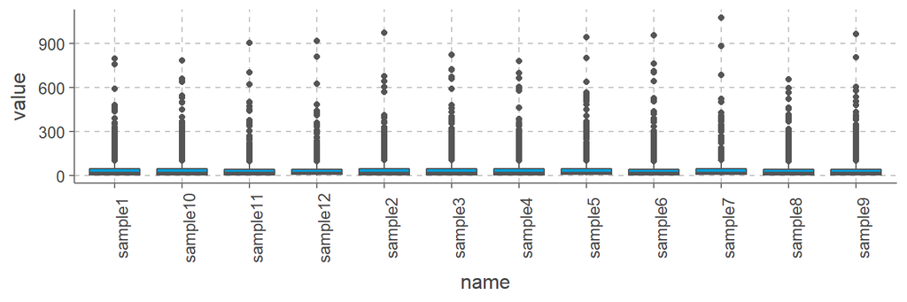

## Data Transformation

- for data visualisation and quality assessment we apply a *variance-stablising transformation*
  - results are on the log\(_2\) scale that we are familiar with

```
##       sample1 sample2 sample3 sample4
## gene1    4.10    4.48    4.37    4.38
## gene2    4.26    3.71    4.64    3.71
## gene3    4.58    4.57    4.56    4.10
## gene4    4.66    5.60    4.90    4.48
## gene5    4.80    5.33    4.78    4.72
## gene6    5.42    5.44    5.15    5.25
```

## Data Transformation

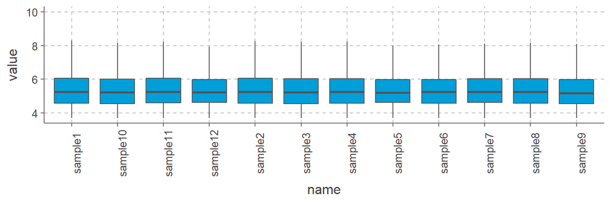

## Principal Components Analysis (PCA)

- *PCA* is commonly-used to check sample relationships
- It determines sources of variation and puts them in order
- Plot the first 2 (sometimes 3) components against each other
- Performed without knowledge of the sample groups; these are overlaid afterwards
- N.B. Easier to run than it is to explain!

## Principal Components Analysis (PCA)

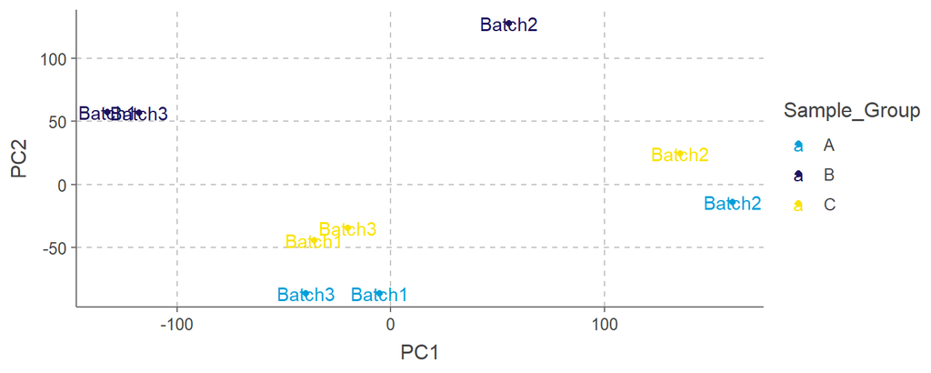

- we want to compare Sample Groups (A vs B, A vs C) etc
- however, the main separation on x-axis is *Batch*
- would be a real problem if we hadn’t been careful with *experimental design*
  - if batch was confounded with sample group we would never trust our results

## Principal Components Analysis (PCA)

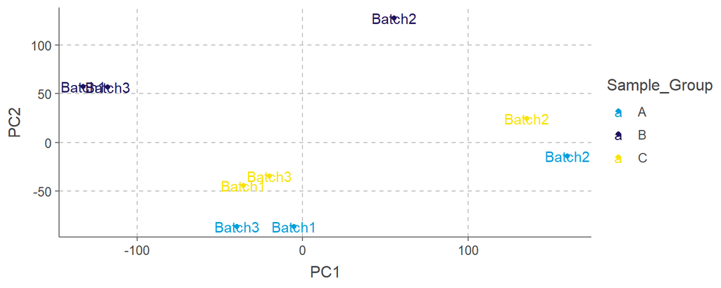

- can also reveal *outlier* samples and *sample swaps*
- need to check lab notes or RNA quality before taking action

## Principal Components Analysis (PCA)

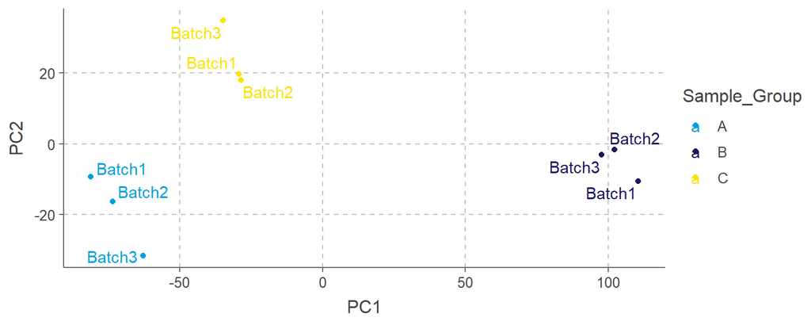

- what it *should* look like
- there are methods for correcting the batch effect

## Further viewing

- [A gentle introduction to RNA-seq](https://youtu.be/tlf6wYJrwKY) - 18 minutes
- [Principal Components Analysis](https://www.youtube.com/watch?v=0Jp4gsfOLMs) - 9 minutes